# Lesson 8

## Question 1:

Create a histogram of diamond prices. Facet the histogram by diamond color and use cut to color the histogram bars. The plot should look something like this: http://i.imgur.com/b5xyrOu.jpg

Note: In the link, a color palette of type ‘qual’ was used to color the histogram using scale_fill_brewer(type = ‘qual’)

This assignment is not graded and will be marked as correct when you submit.

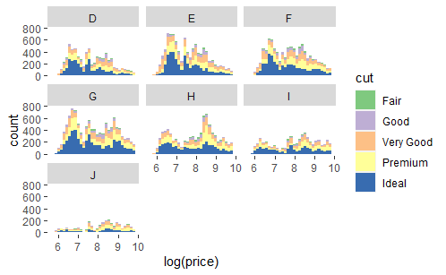

```r
library(ggplot2)
ggplot(data = diamonds, aes(x = log(price), fill=cut)) +
  facet_wrap( ~ color) +
  geom_histogram() +
  scale_fill_brewer(type = 'qual') +
  theme(panel.background = element_blank())
```

## Question 2:

Create a scatterplot of diamond price vs.table and color the points by the cut of the diamond. The plot should look something like this. http://i.imgur.com/rQF9jQr.jpg

Note: In the link, a color palette of type ‘qual’ was used to color the scatterplot using scale_color_brewer(type = ‘qual’)

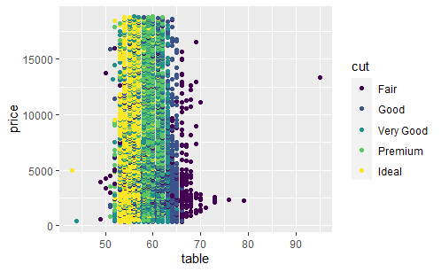

```r
library(ggplot2)
ggplot(data = diamonds, aes(x = table, y=price, color=cut)) +
  geom_point()+
  scale_fill_brewer(type = 'qual')
```

## Question 4:

Create a scatterplot of diamond price vs.volume (x * y * z) and color the points by the clarity of diamonds. Use scale on the y-axis to take the log10 of price. You should also omit the top 1% of diamond volumes from the plot.

Note: Volume is a very rough approximation of a diamond’s actual volume. The plot should look something like this. http://i.imgur.com/excUpea.jpg

Note: In the link, a color palette of type ‘div’ was used to color the scatterplot using scale_color_brewer(type = ‘div’)

```
for 'x', which will replace the existing scale.
for 'y', which will replace the existing scale.
```

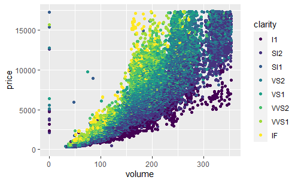

```r
library(ggplot2)
diamonds$volume = (diamonds$x * diamonds$y * diamonds$z)
ggplot(data = diamonds, aes(x = volume , y=price, color=clarity)) +
  geom_point()+
  scale_y_log10()+
  scale_x_log10()+
  xlim(0, quantile(diamonds$volume, 0.99)) +
  ylim(0, quantile(diamonds$price, 0.99)) +
  scale_fill_brewer(type = 'qual')
```

## Question 5:

Many interesting variables are derived from two or more others. For example, we might wonder how much of a person’s network on a service like Facebook the user actively initiated. Two users with the same degree (or number of friends) might be very different if one initiated most of those connections on the service, while the other initiated very few. So it could be useful to consider this proportion of existing friendships that the user initiated. This might be a good predictor of how active a user is compared with their peers, or other traits, such as personality (i.e., is this person an extrovert?).

Your task is to create a new variable called ‘prop_initiated’ in the Pseudo-Facebook data set. The variable should contain the proportion of friendships that the user initiated.

```r
setwd('C:/Users/usaurio/Documents//R/estudos/bases/')
pf <- read.delim('pseudo_facebook.tsv')

pf$prop_initiated <- with(pf, friendships_initiated/friend_count)
```

## Question 6:

Create a line graph of the median proportion of friendships initiated (‘prop_initiated’) vs.tenure and color the line segment by year_joined.bucket.

Recall, we created year_joined.bucket in Lesson 5 by first creating year_joined from the variable tenure. Then, we used the cut function on year_joined to create four bins or cohorts of users.

(2004, 2009] (2009, 2011] (2011, 2012] (2012, 2014]

The plot should look something like this. http://i.imgur.com/vNjPtDh.jpg OR this http://i.imgur.com/IBN1ufQ.jpg

```r
setwd('C:/Users/usaurio/Documents//R/estudos/bases/')
pf <- read.delim('pseudo_facebook.tsv')

pf$prop_initiated <- with(pf, friendships_initiated/friend_count)

pf$year_joined <- 2014 - ceiling(pf$tenure/365)
pf$year_joined.bucket <- cut(pf$year_joined, breaks = c(2004, 2009, 2011, 2012, 2014))

ggplot(aes(x = tenure, y = prop_initiated),
       data = subset(pf, tenure > 0)) +

  geom_line(aes(color = year_joined.bucket), stat = 'summary', fun.y = mean)
```

[output not shown]

## Questão 7

Smooth the last plot you created of of prop_initiated vs tenure colored by year_joined.bucket. You can bin together ranges of tenure or add a smoother to the plot.

There won’t be a solution image for this exercise. You will answer some questions about your plot in the next two exercises.

```r
setwd('C:/Users/usaurio/Documents//R/estudos/bases/')
```

```
The working directory was changed to C:/Users/usaurio/Documents/R/estudos/bases inside a notebook chunk. The working directory will be reset when the chunk is finished running. Use the knitr root.dir option in the setup chunk to change the working directory for notebook chunks.
```

```
Ignoring unknown parameters: fun.y
```

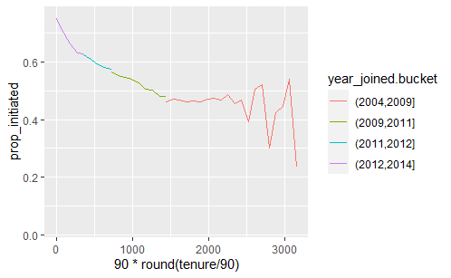

```r
pf <- read.delim('pseudo_facebook.tsv')

pf$prop_initiated <- with(pf, friendships_initiated/friend_count)

pf$year_joined <- 2014 - ceiling(pf$tenure/365)
pf$year_joined.bucket <- cut(pf$year_joined, breaks = c(2004, 2009, 2011, 2012, 2014))

ggplot(aes(x = 90 * round(tenure / 90), y = prop_initiated),
       data = subset(pf, tenure > 0)) +

  geom_line(aes(color = year_joined.bucket), stat = 'summary', fun.y = mean)
```

## Questão 8

The group’s average for the group with the largest proportion of friends_iniciated.

```r
group <- subset(pf, year_joined>2012 & prop_initiated>0)
mean(group$prop_initiated)
```

```
[1] 0.6745182
```

## Questão 10

Create a scatter plot of the price/carat ratio of diamonds. The variable x should be assigned to cut. The points should be colored by diamond color, and the plot should be faceted by clarity.

The plot should look something like this. http://i.imgur.com/YzbWkHT.jpg.

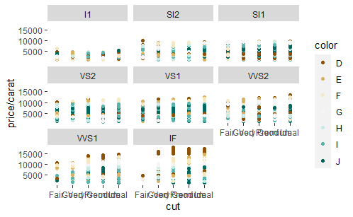

```r
library(ggplot2)
ggplot(data = diamonds, aes(x = cut, y=price/carat, color=color)) +
  facet_wrap( ~ clarity) +
  geom_point()+
  scale_color_brewer(type = 'div') +
  theme(panel.background = element_blank())
```